# Geocoded data compiling

Andrea Molino

November 26, 2024

This Rmarkdown was created to pull in all of the publicly available geocoded, census tract level data that I will be using in my dissertation Aim 1. The final product will be a single data file with all of my geocoded variables, with one row for each census tract in Washington. I will be using 2020 Census tract boundaries. The following variables will be pulled from the following sources:

- **CDC ATSDR**:
  - State-based Social Vulnerability Index (SVI)
- **University of Michigan National Neighborhood Data Archive (NaNDA)**:
  - Neighborhood affluence
- **2020 5-year American Community Survey estimates (table listed along with variable description)**:
  - Housing cost burden - B25106
  - Renter-occupied household status - B25008
  - Poverty status - C17002
  - Median income - B21004
  - Unemployment status - B23025
  - Vehicle access - B08201

# CDC ASTDR: State-based SVI

This section pulls in the state-based social vulnerability index (SVI) that was downloaded directly from the [CDC website](https://www.atsdr.cdc.gov/placeandhealth/svi/data_documentation_download.html). The variable we are using here is `RPL_THEMES`, which is the overall state-based SVI score FROM the Washington specific data download. I also pulled the `RPL_THEMES` variable from the entire United States data download to compare the two.

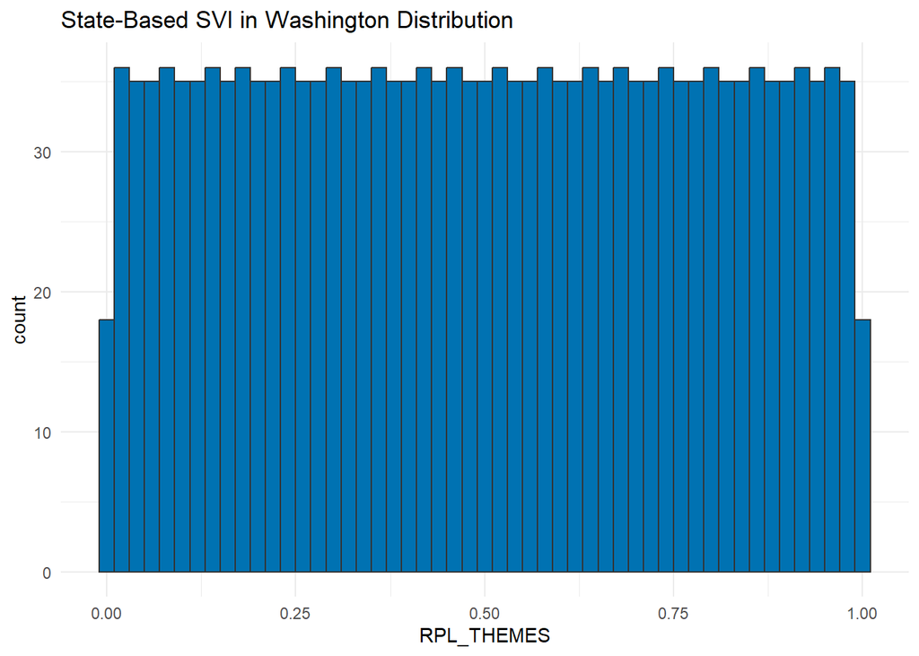

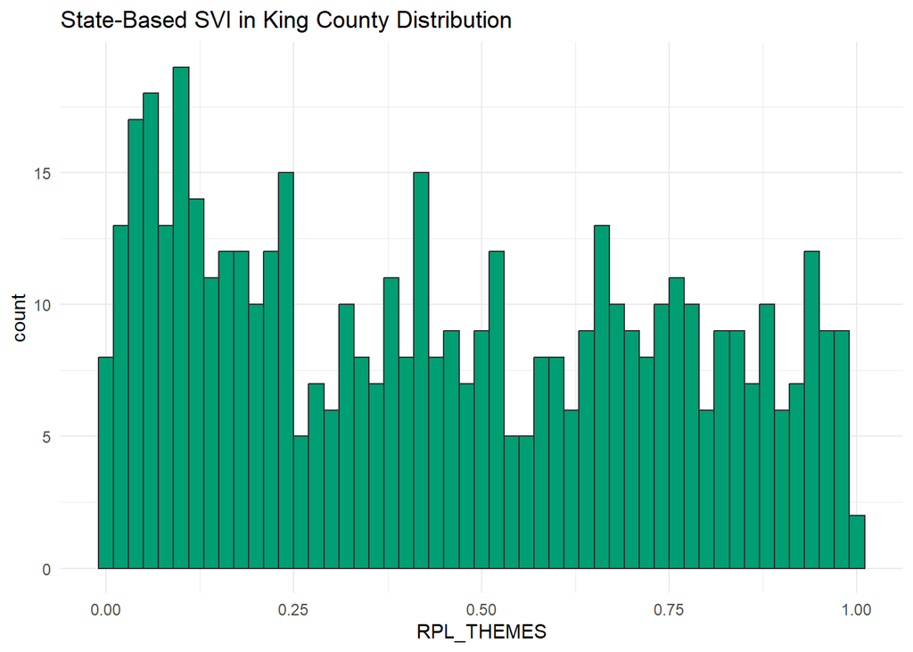

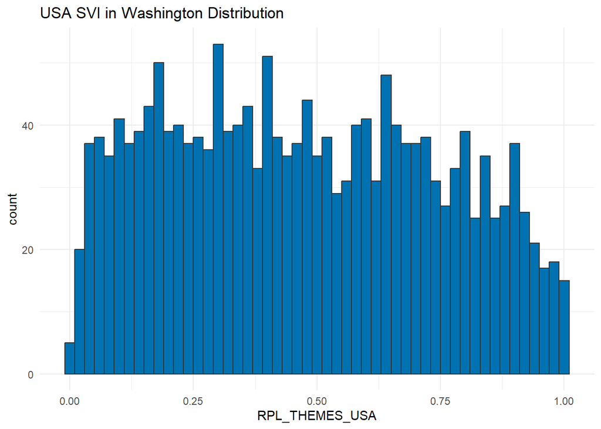

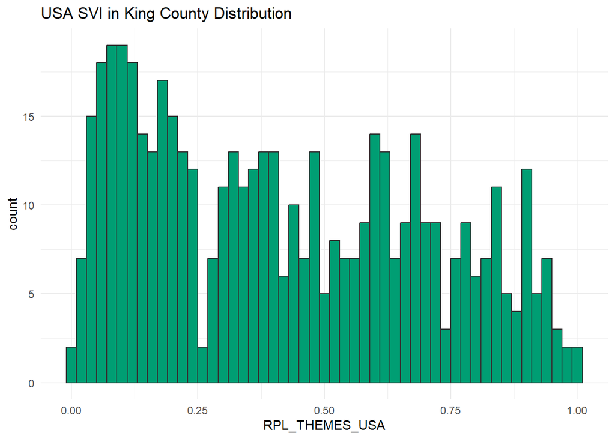

# University of Michigan NaNDA: Neighborhood Affluence

The data source for neighborhood affluence can be found [here](https://nanda.isr.umich.edu/data/). It comes from the University of Michigan National Neighborhood Data Archive, or NaNDA. The variable of interest is `AFFLUENCE16_20`. This data source can be found by going to the website, clicking on “Data”, then “Socioeconomic Status and Demographic Characteristics”, which will take you to a data download option. I downloaded the data in “R” format, and is stored in the ICPSR_38528 folder. There are 5 folders of data, and we are using “DS0004”, as is the data set for 2016-2020 data for Census Tracts.

```
##    Min. 1st Qu.  Median    Mean 3rd Qu.    Max.    NA's
## 0.01042 0.22959 0.32551 0.36233 0.46673 0.88978      14
```

|  | GEOID | AFFLUENCE16_20 | PED3_16_20 | PFAMINCGE125K16_20 | PPROF16_20 | AFFLUENCE16_20_armcreate |
| --- | --- | --- | --- | --- | --- | --- |
| 1 | 53001950100 | 0.24030173 | 0.22861934 | 0.17580645 | 0.3164794 | 0.24030173 |
| 2 | 53001950200 | 0.16629490 | 0.20503597 | 0.06557377 | 0.2282750 | 0.16629490 |
| 3 | 53001950301 | 0.09228202 | 0.05701754 | 0.03007519 | 0.1897533 | 0.09228202 |
| 4 | 53001950302 | 0.11982214 | 0.07709923 | 0.15168539 | 0.1306818 | 0.11982214 |
| 5 | 53001950303 | 0.20413511 | 0.14538746 | 0.24867725 | 0.2183406 | 0.20413511 |
| 6 | 53001950400 | 0.19595528 | 0.18115501 | 0.16376811 | 0.2429427 | 0.19595527 |

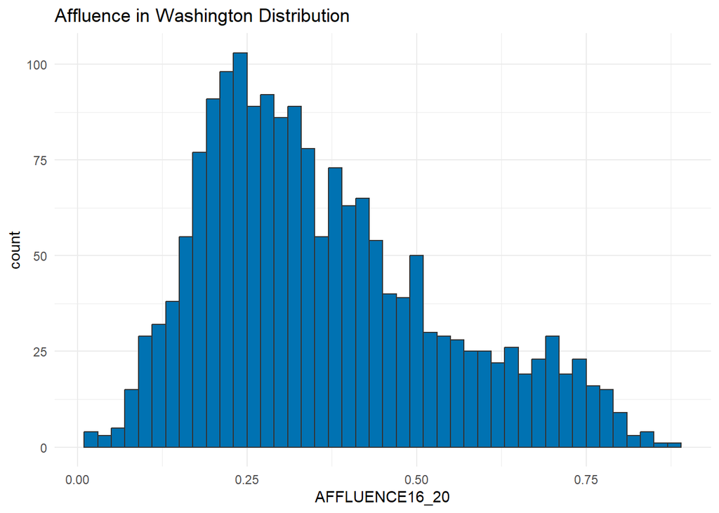

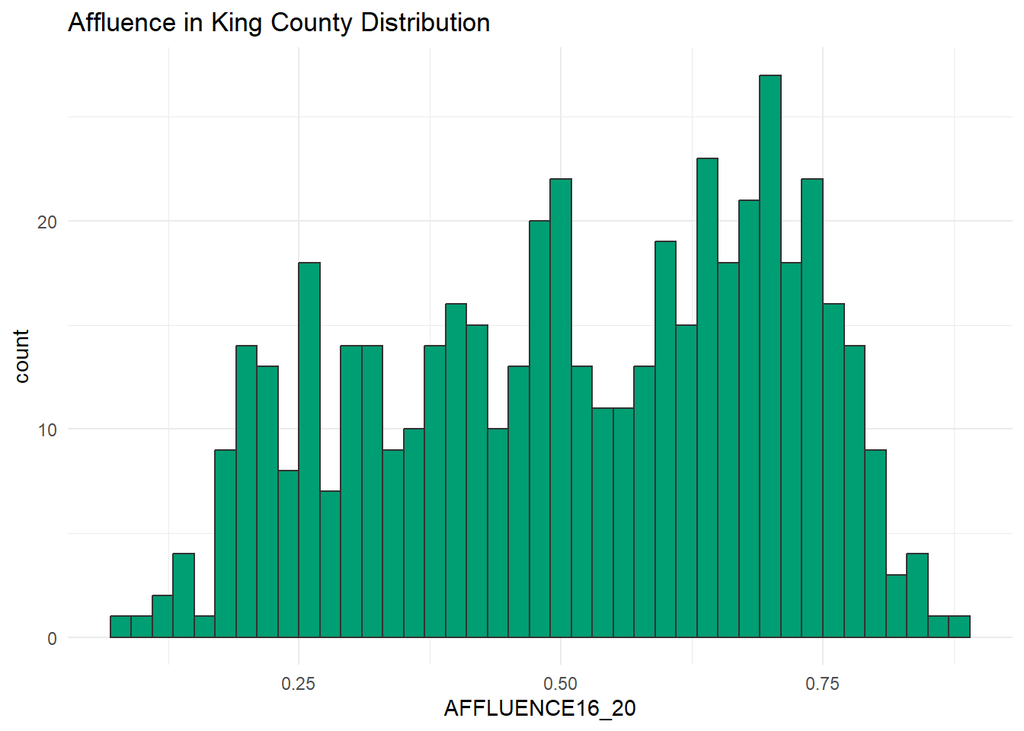

# American Community Survey

This is the data source for the six remaining census tract-level effect modifiers, specifically:

- Housing cost burden - B25106
- Renter-occupied household status - B25008
- Poverty status - C17002
- Median income - B21004
- Unemployment status - B23025
- Vehicle access - B08201

While all of these variables/values can technically be pulled from the Census’s data tables (links below), I opted to use the `tidycensus` R package for reproducibility purposes. The `tidycensus` package allows for easy access to the Census API, and the package is updated regularly to ensure that the data being pulled is the most recent. The reference manual can be found [here](https://cran.r-project.org/web/packages/tidycensus/tidycensus.pdf).

I also used Social Explorer to identify the correct variable names for the 2020 5-year estimate ACS tables. The ACS tables can be found [here](https://www.socialexplorer.com/data/ACS2020_5yr/metadata/?ds=ACS20_5yr).

## Housing cost burden: B25106

The ACS Table used for these estimates is B25106: “TENURE BY HOUSING COSTS AS A PERCENTAGE OF HOUSEHOLD INCOME IN THE PAST 12 MONTHS”. The ACS table can be found [here](https://data.census.gov/table/ACSDT5Y2020.B25106?q=B25106:%20Tenure%20by%20Housing%20Costs%20as%20a%20Percentage%20of%20Household%20Income%20in%20the%20Past%2012%20Months&g=040XX00US53). The Social Explorer table names can be found [here](https://www.socialexplorer.com/data/ACS2020_5yr/metadata/?ds=ACS20_5yr&table=B25106).

This ACS table includes a row for owner-occupied housing units with “zero or negative income”, as well as renter-occupied housing units with “zero or negative income” as well as a row for “no cash rent”. Per the Harvard Joint Center for Housing Studies, “housing cost burden”, moderate or higher, is defined as spending 30% or more of one’s income on housing. They state that they deal with the “zero or negative income” and “no cash rent” groups as follows: “Households with zero or negative income are assumed to have burdens, and households that are not required to pay rent are assumed to be unburdened”. See Figure 3 Notes in the [JCHS report here](https://www.jchs.harvard.edu/sites/default/files/reports/files/Harvard_JCHS_Americas_Rental_Housing_2024.pdf). I incorporated this approach into my code below for calculating housing cost burden.

**VARIABLE DEFINITION**: percentage of occupied housing units that spend 30% or more of their income on housing, including both renter- and owner-occupied housing units

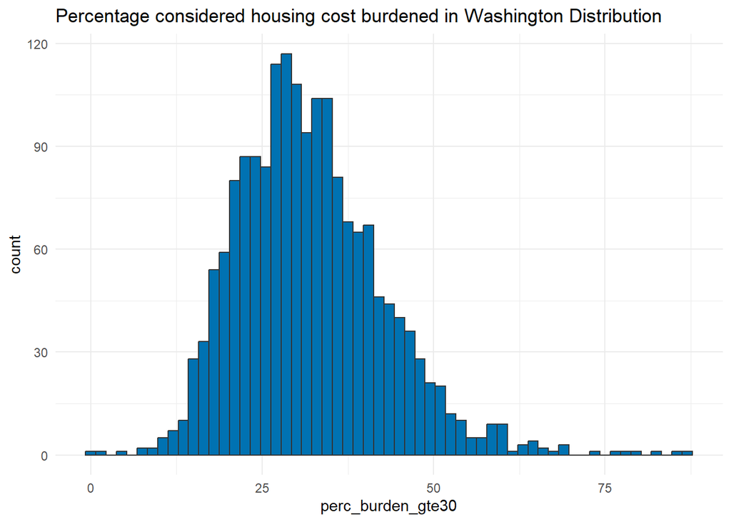

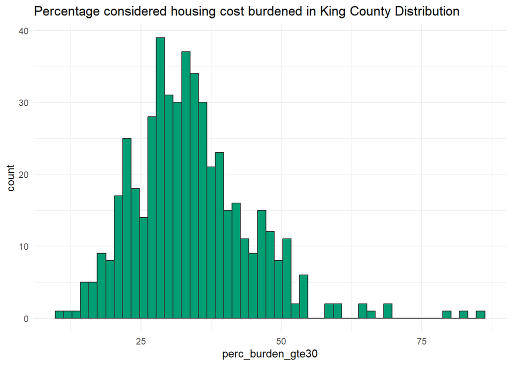

## Renter-occupied household status: B25008

The ACS Table used for these estimates is B25008: “TOTAL POPULATION IN OCCUPIED HOUSING UNITS BY TENURE”. The ACS table can be found [here](https://data.census.gov/table/ACSDT5Y2020.B25008?q=B25008&g=040XX00US53). The Social Explorer table names can be found [here](https://www.socialexplorer.com/data/ACS2020_5yr/metadata/?ds=ACS20_5yr&table=B25008).

**VARIABLE DEFINITION**: percentage of the total population who live in occupied housing units that are renters

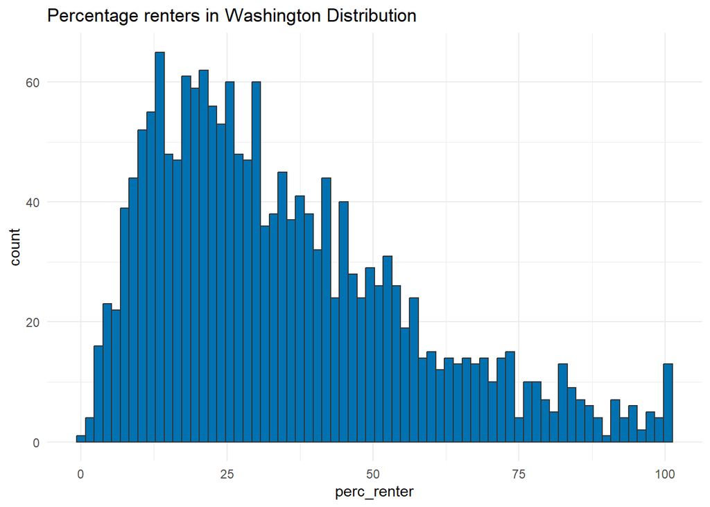

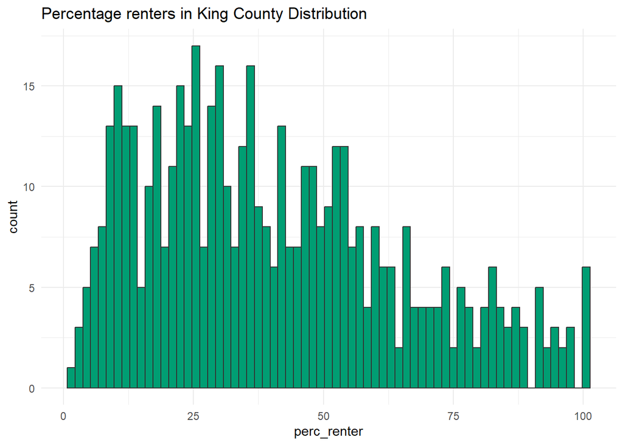

## Poverty status: C17002

The ACS Table used for these estimates is C17002: “RATIO OF INCOME TO POVERTY LEVEL IN THE PAST 12 MONTHS”. The ACS table can be found [here](https://data.census.gov/table?q=C17002:%20Ratio%20of%20Income%20to%20Poverty%20Level%20in%20the%20Past%2012%20Months&g=040XX00US53). The Social Explorer table names can be found [here](https://www.socialexplorer.com/data/ACS2020_5yr/metadata/?ds=ACS20_5yr&table=C17002).

I was initially planning to use [ACS Table S1701](https://data.census.gov/table?q=S1701:%20Poverty%20Status%20in%20the%20Past%2012%20Months&g=040XX00US53). However, this type of table cannot be pulled into R using `tidycensus`, so I opted to use C17002 instead. I made sure that I could get the correct number of people below 150% of the poverty level from Table S1701 in Washington using Table C17002. With Table C17002, I can get the total population below 150% of the poverty level by adding C17002_002 through C17002_005.

**VARIABLE DEFINITION**: percentage of the total population for whom poverty status is determined who are below 150% of the poverty level in the past 12 months (i.e., ratio of income to poverty level in the past 12 months is <1.50)

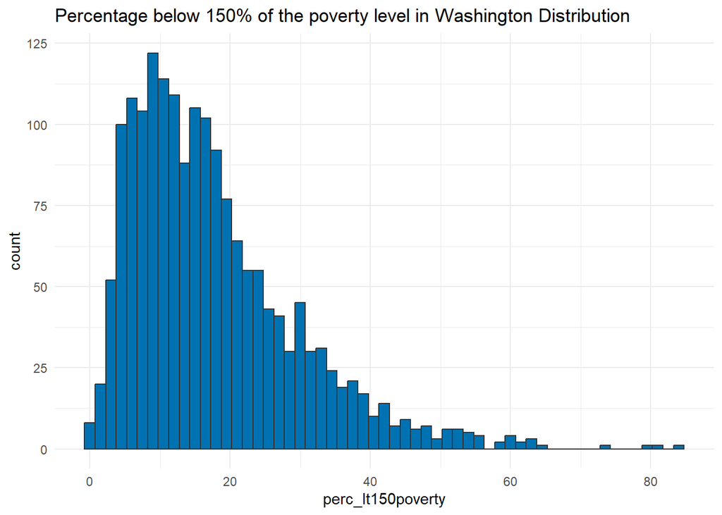

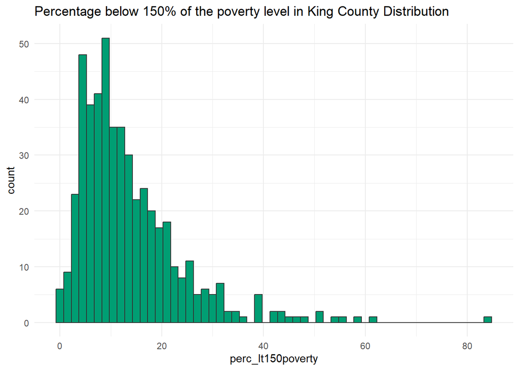

## Median income: B21004

The ACS Table used for these estimates is B21004: “MEDIAN INCOME IN THE PAST 12 MONTHS (IN 2020 INFLATION-ADJUSTED DOLLARS) BY VETERAN STATUS BY SEX FOR THE CIVILIAN POPULATION 18 YEARS AND OVER WITH INCOME”. The ACS table can be found here. The Social Explorer table names can be found [here](https://www.socialexplorer.com/data/ACS2020_5yr/metadata/?ds=ACS20_5yr&table=B21004). Though this table is stratified into veteran vs. nonveteran status, I am only taking the “total” population, so it is the median income for the entire civilian population.

**VARIABLE DEFINITION**: median income in the past 12 months (in 2020 inflation-adjusted US dollars) for those over the age of 18 years with income

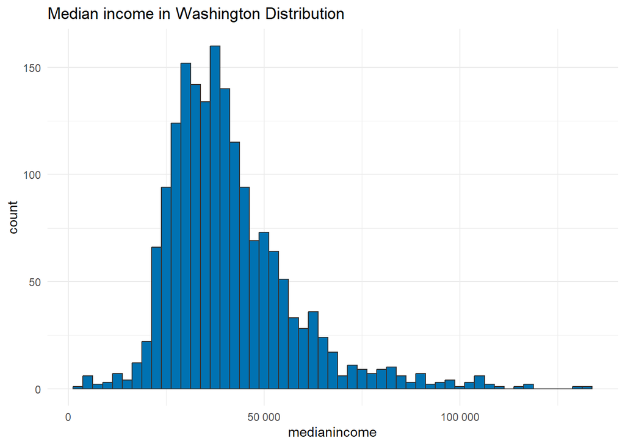

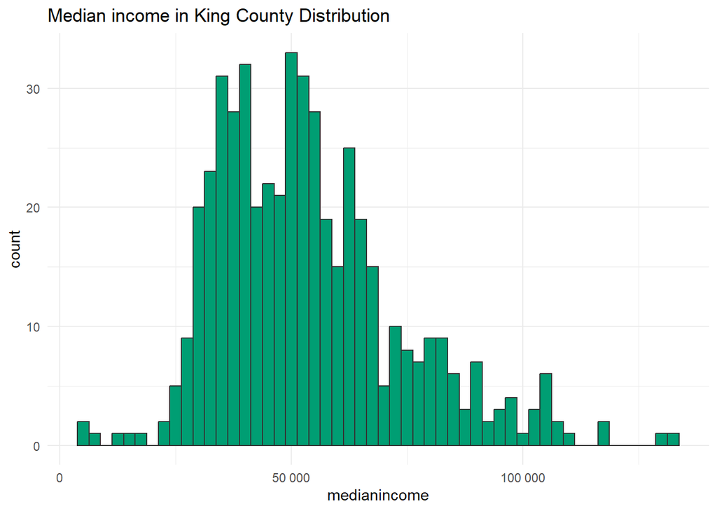

## Unemployment status - B23025

The ACS Table used for these estimates is B23025: “EMPLOYMENT STATUS FOR THE POPULATION 16 YEARS AND OVER”. The ACS table can be found [here](https://data.census.gov/table?q=B23025:%20Employment%20Status%20for%20the%20Population%2016%20Years%20and%20Over&g=040XX00US53). The Social Explorer table names can be found [here](https://www.socialexplorer.com/data/ACS2020_5yr/metadata/?ds=ACS20_5yr&table=B23025).

There were a few unemployment variables to choose from, but this one was selected to align as closely as possible with the Bureau of Labor Statistics unemployment statistics, which defines the labor force specifically as the civilian, non-institutionalized labor force, which includes all people age 16 and older who are classified as either employed and unemployed (BLS information [here](https://www.bls.gov/cps/definitions.htm)). Thus, my definition will exclude those in the armed forces and those not in the labor force.

**VARIABLE DEFINITION**: percentage of the civilian population over 16 years of age in the labor force who are unemployed

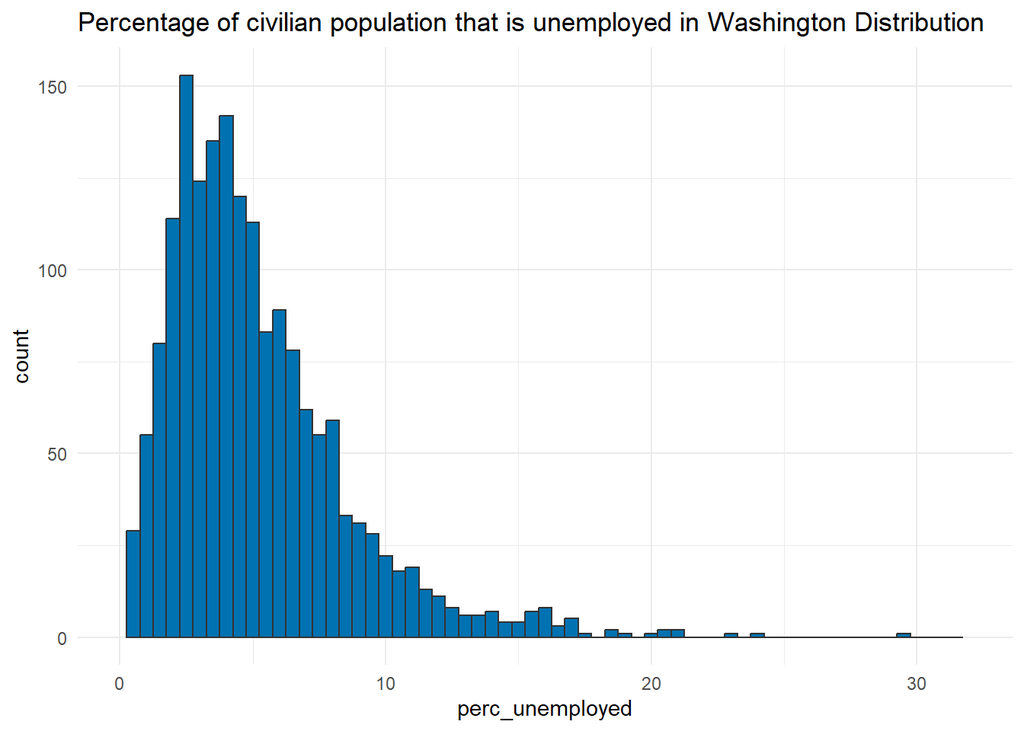

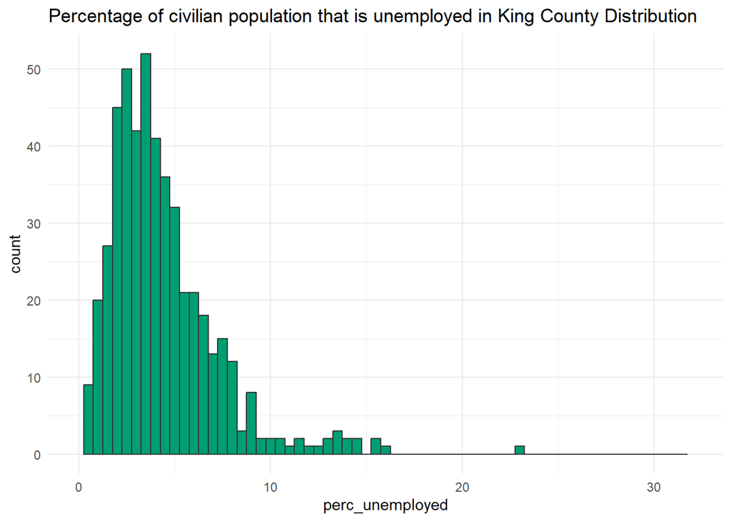

## Vehicle access - B08201

The ACS Table used for these estimates is B08201: “HOUSEHOLD SIZE BY VEHICLES AVAILABLE”. The ACS table can be found [here](https://data.census.gov/table/ACSDT5Y2020.B08201?q=B08201:%20Household%20Size%20by%20Vehicles%20Available&g=040XX00US53). The Social Explorer table names can be found [here](https://www.socialexplorer.com/data/ACS2020_5yr/metadata/?ds=ACS20_5yr&table=B08201). I decided to use this variable based on a presentation I saw looking at vehicle access and prenatal healthcare utilization in Allegheny County in Pennsylvania while at CSTE. I talked to the analyst on the abstract afterwards. Here is a [report](https://www.alleghenycounty.us/files/assets/county/v/1/services/dhs/documents/annual-plans-and-budgets/csbg/2021-community-needs-assessment-economic-security.pdf) from this county using this ACS variable (Figure 16).

**VARIABLE DEFINITION**: percentage of households with no vehicle access regardless of household size

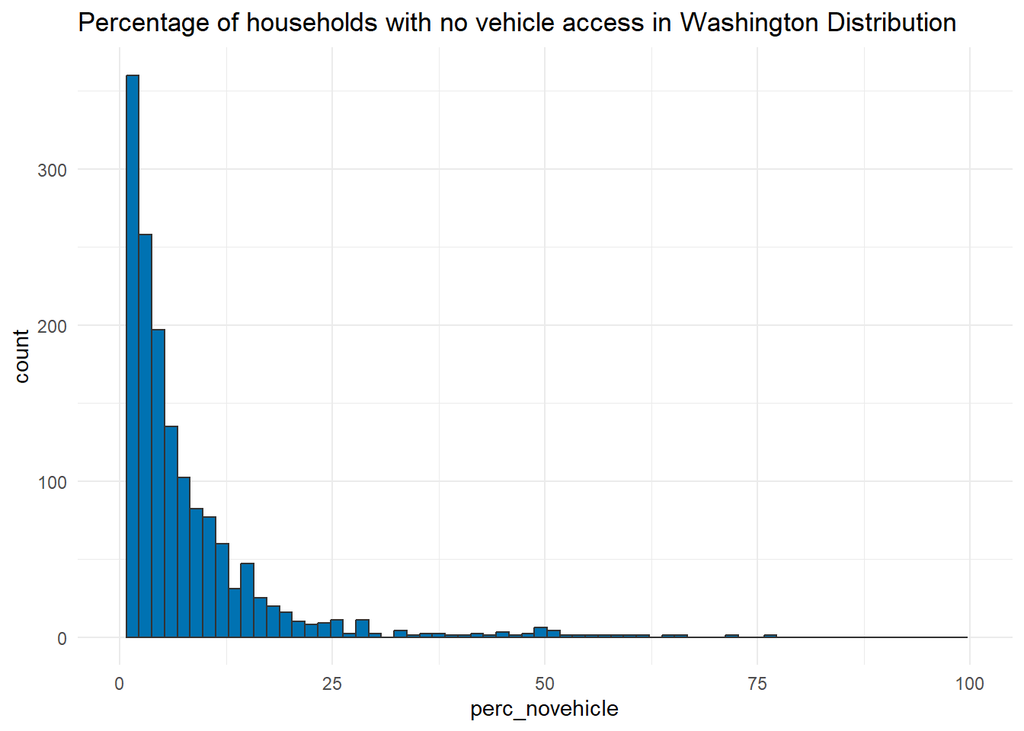

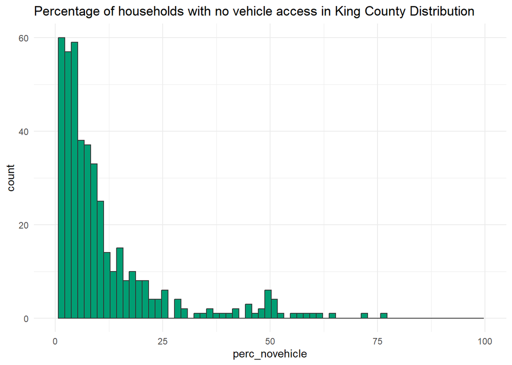

# Create quartiles for all data frames

Here is where I created quartiles for all the variables of interest within their own data frames. The coding scheme here is 1 for the BEST SES (i.e., “higher” SES) tracts, and 4 for the WORST SES (i.e., “lower” SES) tracts. This applies to all 8 geocoded variables I am working with for this analysis. I am doing one 1-4 scale for each variable for Washington State, and then again for King County.

# Merging all together for 1 unified data set

Here, I combine all 8 datasets for all 8 geocoded variables that can be sent to KPWA and merged with STEP data at the census tract level to create a final, unified dataset.

# Assessing missingness of variables for census tracts

I also assess for missingness of the variables of interest in the final dataset.

|  | Overall (N=1784) |
| --- | --- |
| factor(RPL_THEMES_QUARTILE_WA) |  |
| 1 | 443 (24.8%) |
| 2 | 442 (24.8%) |
| 3 | 442 (24.8%) |
| 4 | 442 (24.8%) |
| Missing | 15 (0.8%) |
| factor(affluence_quartile_WA) |  |
| 1 | 442 (24.8%) |
| 2 | 442 (24.8%) |
| 3 | 443 (24.8%) |
| 4 | 443 (24.8%) |
| Missing | 14 (0.8%) |
| factor(perc_burden_gte30_quartile_WA) |  |
| 1 | 443 (24.8%) |
| 2 | 442 (24.8%) |
| 3 | 442 (24.8%) |
| 4 | 442 (24.8%) |
| Missing | 15 (0.8%) |
| factor(perc_renter_quartile_WA) |  |
| 1 | 443 (24.8%) |
| 2 | 442 (24.8%) |
| 3 | 442 (24.8%) |
| 4 | 442 (24.8%) |
| Missing | 15 (0.8%) |
| factor(perc_lt150poverty_quartile_WA) |  |
| 1 | 443 (24.8%) |
| 2 | 442 (24.8%) |
| 3 | 442 (24.8%) |
| 4 | 442 (24.8%) |
| Missing | 15 (0.8%) |
| factor(medianincome_quartile_WA) |  |
| 1 | 442 (24.8%) |
| 2 | 442 (24.8%) |
| 3 | 442 (24.8%) |
| 4 | 442 (24.8%) |
| Missing | 16 (0.9%) |
| factor(perc_unemployed_quartile_WA) |  |
| 1 | 443 (24.8%) |
| 2 | 442 (24.8%) |
| 3 | 442 (24.8%) |
| 4 | 442 (24.8%) |
| Missing | 15 (0.8%) |
| factor(perc_novehicle_quartile_WA) |  |
| 1 | 443 (24.8%) |
| 2 | 442 (24.8%) |
| 3 | 442 (24.8%) |
| 4 | 442 (24.8%) |
| Missing | 15 (0.8%) |

```
##    missing_quart
## 1    53005012000
## 2    53009990100
## 3    53021980100
## 4    53025011404
## 5    53027990000
## 6    53029992201
## 7    53031990000
## 8    53033990100
## 9    53035081400
## 10   53035990100
## 11   53049990100
## 12   53055990100
## 13   53057990100
## 14   53061990002
## 15   53061990100
## 16   53067990100
## 17   53071920400
```